# Projek Github Pemro

Kelompok 1

2025-10-22

# 1. Instalasi & Pemanggilan Paket

```r
packages <- c("tidyverse", "readxl", "MASS", "AER", "pscl", "GGally")
install.packages(setdiff(packages, rownames(installed.packages())))

library(tidyverse)
library(readxl)
library(MASS)
library(AER)
library(pscl)
```

```r
library(GGally)
library(ggplot2)
```

# 2. Eksplorasi Data

## import data

```r
df <- read_excel("D:/KULIAH/Magister/Pemrograman Statistika/data_final_bersih.xlsx")
```

## Cek struktur dan ringkasan

```r
str(df)
```

```
## tibble [23 × 7] (S3: tbl_df/tbl/data.frame)
##  $ Satuan Wilayah Hukum                                                        : chr [1:23] "Polres Bogor" "Polres Ciamis" "Polres Cianjur" "Polres Cimahi" ...
##  $ Jumlah Kejahatan yang Dilaporkan                                            : num [1:23] 4030 1077 1951 2402 938 ...
##  $ besaran_upah_minimum                                                        : num [1:23] 4579541 2089464 2915102 3568279 2533038 ...
##  $ kepadatan_penduduk                                                          : num [1:23] 1.94 813 727 7.6 9.04 ...
##  $ Produk Domestik Regional Bruto per Kapita Atas Dasar Harga Berlaku (Ribu Rp): num [1:23] 54857 34336 24914 52514 88560 ...
##  $ tingkat_pengangguran_terbuka                                                : num [1:23] 7.34 3.37 5.99 7.84 6.29 ...
##  $ putus_sekolah                                                               : num [1:23] 24 5 27 15.5 1 74 8 3 0 3 ...
```

```r
summary(df)
```

```
##  Satuan Wilayah Hukum Jumlah Kejahatan yang Dilaporkan besaran_upah_minimum
##  Length:23            Min.   : 203.0                   Min.   :2070192
##  Class :character     1st Qu.: 892.5                   1st Qu.:2387801
##  Mode  :character     Median :1463.0                   Median :2834399
##                       Mean   :1602.6                   Mean   :3130211
##                       3rd Qu.:2076.5                   3rd Qu.:3548123
##                       Max.   :4036.0                   Max.   :5257834
##  kepadatan_penduduk
##  Min.   :  1.030
##  1st Qu.:  2.074
##  Median :  9.036
##  Mean   :298.343
##  3rd Qu.:732.500
##  Max.   :954.000
##  Produk Domestik Regional Bruto per Kapita Atas Dasar Harga Berlaku (Ribu Rp)
##  Min.   : 24914
##  1st Qu.: 30220
##  Median : 39445
##  Mean   : 50447
##  3rd Qu.: 55012
##  Max.   :147081
##  tingkat_pengangguran_terbuka putus_sekolah
##  Min.   :1.580                Min.   : 0.00
##  1st Qu.:6.075                1st Qu.: 1.00
##  Median :6.730                Median : 5.00
##  Mean   :6.323                Mean   :10.93
##  3rd Qu.:7.370                3rd Qu.:16.25
##  Max.   :8.340                Max.   :74.00
```

```r
num_df <- df[sapply(df, is.numeric)]
```

## Scatterplot matrix antar variabel numerik

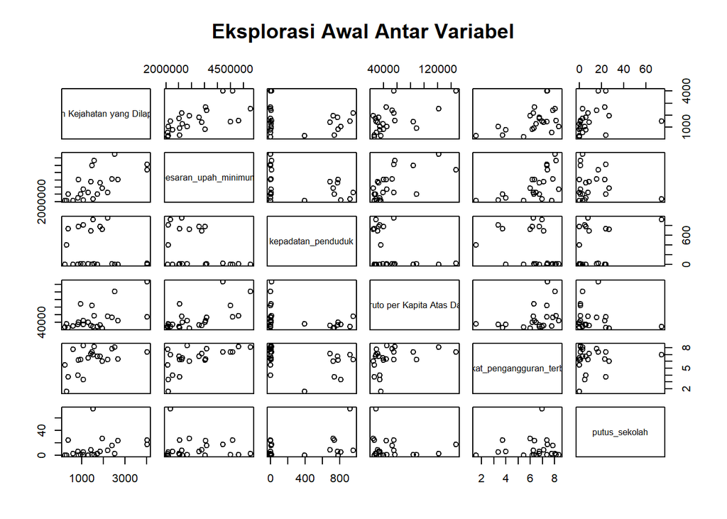

```r
pairs(num_df, main = "Eksplorasi Awal Antar Variabel")
```

1. Jumlah kejahatan yang dilaporkan vs besaran upah minimum

Terlihat cenderung meningkat bersama — daerah dengan upah minimum lebih tinggi memiliki jumlah kejahatan yang lebih banyak.

2. Jumlah kejahatan vs kepadatan penduduk

3. Jumlah kejahatan vs PDRB per kapita

4. Jumlah kejahatan vs tingkat pengangguran terbuka

Terdapat indikasi korelasi positif: beberapa daerah dengan pengangguran tinggi memiliki kejahatan tinggi juga.

5. Jumlah kejahatan vs putus sekolah

Tampak tidak ada pola yang jelas, namun ada kemungkinan daerah dengan tingkat putus sekolah lebih tinggi cenderung memiliki lebih banyak kejahatan.

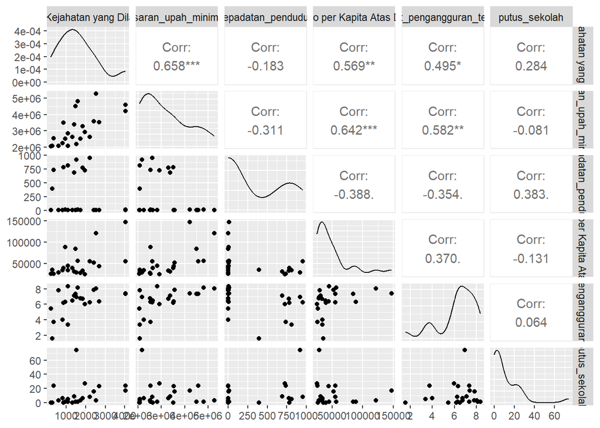

```r
# Versi lebih informatif (dari GGally)
ggpairs(num_df)
```

🔹 Hubungan antara variabel dependen dan independen

1. Kejahatan yang Dilaporkan vs Besaran Upah Minimum

Korelasi: 0.658* (signifikan tinggi, positif)

Interpretasi: Semakin tinggi upah minimum di suatu daerah, semakin tinggi pula jumlah kejahatan yang dilaporkan.

2. Kejahatan yang Dilaporkan vs PDRB per Kapita

Korelasi: 0.569 (signifikan, positif)

Interpretasi: Daerah dengan tingkat kesejahteraan (PDRB per kapita) yang lebih tinggi juga cenderung memiliki laporan kejahatan lebih banyak.

3. Kejahatan yang Dilaporkan vs Tingkat Pengangguran Terbuka

Korelasi: 0.495 (signifikan, positif)

Interpretasi: Semakin tinggi tingkat pengangguran, semakin besar pula jumlah kejahatan yang dilaporkan.

4. Kejahatan yang Dilaporkan vs Kepadatan Penduduk

Korelasi: –0.183 (lemah, negatif)

Interpretasi: Tidak terdapat hubungan berarti antara kepadatan penduduk dan jumlah kejahatan yang dilaporkan.

5. Kejahatan yang Dilaporkan vs Putus Sekolah

Korelasi: 0.284 (lemah, positif)

Interpretasi: Ada sedikit kecenderungan bahwa daerah dengan angka putus sekolah lebih tinggi melaporkan lebih banyak kejahatan, meski hubungannya lemah dan tidak signifikan.

🔹 Hubungan antar variabel independen (potensi multikolinearitas)

1. Besaran Upah Minimum vs PDRB per Kapita

Korelasi: 0.642* (kuat, positif)

Artinya, daerah dengan PDRB tinggi biasanya juga memiliki upah minimum tinggi → menunjukkan potensi multikolinearitas.

2. Besaran Upah Minimum vs Tingkat Pengangguran Terbuka

Korelasi: 0.582 (cukup kuat, positif)

Wilayah dengan upah minimum tinggi juga cenderung memiliki tingkat pengangguran terbuka yang lebih tinggi.

3. Kepadatan Penduduk dengan variabel lain

Korelasi cenderung rendah (< 0.4), menunjukkan bahwa kepadatan penduduk tidak terlalu berhubungan kuat dengan variabel lain.

4. Putus Sekolah dengan variabel lain

Korelasi rendah dengan semua variabel, sehingga kemungkinan tidak menjadi faktor dominan dalam variasi kejahatan.

# 3. Uji Sebaran Poisson pada Peubah Respon

## Peubah respon: Jumlah Kejahatan yang Dilaporkan

```r
Y <- df$`Jumlah Kejahatan yang Dilaporkan`

mean_Y <- mean(Y)
var_Y  <- var(Y)

cat("Mean =", mean_Y, "Var =", var_Y, "\n")
```

```
## Mean = 1602.609 Var = 1073734
```

```r
if (var_Y > mean_Y) {
  cat("Data cenderung overdispersi, model Poisson mungkin kurang tepat.\n")
} else {
  cat("Data mungkin sesuai dengan sebaran Poisson.\n")
}
```

```
## Data cenderung overdispersi, model Poisson mungkin kurang tepat.
```

# 4. Model Regresi Poisson

```r
model_pois <- glm(
  `Jumlah Kejahatan yang Dilaporkan` ~ besaran_upah_minimum + kepadatan_penduduk +
    `Produk Domestik Regional Bruto per Kapita Atas Dasar Harga Berlaku (Ribu Rp)` +
    tingkat_pengangguran_terbuka + putus_sekolah,
  data = df,
  family = poisson
)

summary(model_pois)
```

```
##
## Call:
## glm(formula = `Jumlah Kejahatan yang Dilaporkan` ~ besaran_upah_minimum +
##     kepadatan_penduduk + `Produk Domestik Regional Bruto per Kapita Atas Dasar Harga Berlaku (Ribu Rp)` +
##     tingkat_pengangguran_terbuka + putus_sekolah, family = poisson,
##     data = df)
##
## Coefficients:
##                                                                                 Estimate
## (Intercept)                                                                    5.493e+00
## besaran_upah_minimum                                                           2.748e-07
## kepadatan_penduduk                                                             1.730e-05
## `Produk Domestik Regional Bruto per Kapita Atas Dasar Harga Berlaku (Ribu Rp)` 3.724e-06
## tingkat_pengangguran_terbuka                                                   9.009e-02
## putus_sekolah                                                                  1.331e-02
##                                                                                Std. Error
## (Intercept)                                                                     3.327e-02
## besaran_upah_minimum                                                            7.921e-09
## kepadatan_penduduk                                                              1.871e-05
## `Produk Domestik Regional Bruto per Kapita Atas Dasar Harga Berlaku (Ribu Rp)`  1.872e-07
## tingkat_pengangguran_terbuka                                                    5.266e-03
## putus_sekolah                                                                   3.300e-04
##                                                                                z value
## (Intercept)                                                                    165.096
## besaran_upah_minimum                                                            34.693
## kepadatan_penduduk                                                               0.924
## `Produk Domestik Regional Bruto per Kapita Atas Dasar Harga Berlaku (Ribu Rp)`  19.897
## tingkat_pengangguran_terbuka                                                    17.108
## putus_sekolah                                                                   40.320
##                                                                                Pr(>|z|)
## (Intercept)                                                                      <2e-16
## besaran_upah_minimum                                                             <2e-16
## kepadatan_penduduk                                                                0.355
## `Produk Domestik Regional Bruto per Kapita Atas Dasar Harga Berlaku (Ribu Rp)`   <2e-16
## tingkat_pengangguran_terbuka                                                     <2e-16
## putus_sekolah                                                                    <2e-16
##
## (Intercept)                                                                    ***
## besaran_upah_minimum                                                           ***
## kepadatan_penduduk
## `Produk Domestik Regional Bruto per Kapita Atas Dasar Harga Berlaku (Ribu Rp)` ***
## tingkat_pengangguran_terbuka                                                   ***
## putus_sekolah                                                                  ***
## ---
## Signif. codes:  0 '***' 0.001 '**' 0.01 '*' 0.05 '.' 0.1 ' ' 1
##
## (Dispersion parameter for poisson family taken to be 1)
##
##     Null deviance: 14460  on 22  degrees of freedom
## Residual deviance:  5856  on 17  degrees of freedom
## AIC: 6074.5
##
## Number of Fisher Scoring iterations: 5
```

Model Poisson menunjukkan bahwa variabel upah minimum, PDRB per kapita, pengangguran, dan putus sekolah berpengaruh signifikan positif terhadap jumlah kejahatan, sedangkan variabel kepadatan penduduk tidak signifikan.

# 5. Identifikasi Overdispersi

```r
deviance_ratio <- model_pois$deviance / model_pois$df.residual
cat("Nilai koefisien disperse =", deviance_ratio, "\n")
```

```
## Nilai koefisien disperse = 344.4684
```

```r
if (deviance_ratio > 1.5) {
  cat("Indikasi overdispersi terdeteksi.\n")
} else {
  cat("Tidak ada indikasi overdispersi.\n")
}
```

```
## Indikasi overdispersi terdeteksi.
```

Model Poisson menghasilkan nilai deviance ratio = 344.47, yang jauh lebih besar dari 1.5 — ini menegaskan adanya overdispersi berat.

# 6. Model Regresi Binomial Negatif

```r
model_nb <- glm.nb(
  `Jumlah Kejahatan yang Dilaporkan` ~ besaran_upah_minimum + kepadatan_penduduk +
    `Produk Domestik Regional Bruto per Kapita Atas Dasar Harga Berlaku (Ribu Rp)` +
    tingkat_pengangguran_terbuka + putus_sekolah,
  data = df
)

summary(model_nb)
```

```
##
## Call:
## glm.nb(formula = `Jumlah Kejahatan yang Dilaporkan` ~ besaran_upah_minimum +
##     kepadatan_penduduk + `Produk Domestik Regional Bruto per Kapita Atas Dasar Harga Berlaku (Ribu Rp)` +
##     tingkat_pengangguran_terbuka + putus_sekolah, data = df,
##     init.theta = 4.868568798, link = log)
##
## Coefficients:
##                                                                                 Estimate
## (Intercept)                                                                    5.060e+00
## besaran_upah_minimum                                                           2.831e-07
## kepadatan_penduduk                                                             2.217e-04
## `Produk Domestik Regional Bruto per Kapita Atas Dasar Harga Berlaku (Ribu Rp)` 3.919e-06
## tingkat_pengangguran_terbuka                                                   1.428e-01
## putus_sekolah                                                                  1.240e-02
##                                                                                Std. Error
## (Intercept)                                                                     4.610e-01
## besaran_upah_minimum                                                            1.486e-07
## kepadatan_penduduk                                                              3.077e-04
## `Produk Domestik Regional Bruto per Kapita Atas Dasar Harga Berlaku (Ribu Rp)`  4.138e-06
## tingkat_pengangguran_terbuka                                                    7.441e-02
## putus_sekolah                                                                   6.580e-03
##                                                                                z value
## (Intercept)                                                                     10.976
## besaran_upah_minimum                                                             1.906
## kepadatan_penduduk                                                               0.720
## `Produk Domestik Regional Bruto per Kapita Atas Dasar Harga Berlaku (Ribu Rp)`   0.947
## tingkat_pengangguran_terbuka                                                     1.919
## putus_sekolah                                                                    1.885
##                                                                                Pr(>|z|)
## (Intercept)                                                                      <2e-16
## besaran_upah_minimum                                                             0.0567
## kepadatan_penduduk                                                               0.4713
## `Produk Domestik Regional Bruto per Kapita Atas Dasar Harga Berlaku (Ribu Rp)`   0.3437
## tingkat_pengangguran_terbuka                                                     0.0550
## putus_sekolah                                                                    0.0595
##
## (Intercept)                                                                    ***
## besaran_upah_minimum                                                           .
## kepadatan_penduduk
## `Produk Domestik Regional Bruto per Kapita Atas Dasar Harga Berlaku (Ribu Rp)`
## tingkat_pengangguran_terbuka                                                   .
## putus_sekolah                                                                  .
## ---
## Signif. codes:  0 '***' 0.001 '**' 0.01 '*' 0.05 '.' 0.1 ' ' 1
##
## (Dispersion parameter for Negative Binomial(4.8686) family taken to be 1)
##
##     Null deviance: 52.996  on 22  degrees of freedom
## Residual deviance: 23.805  on 17  degrees of freedom
## AIC: 373.09
##
## Number of Fisher Scoring iterations: 1
##
##
##               Theta:  4.87
##           Std. Err.:  1.40
##
##  2 x log-likelihood:  -359.094
```

Pada taraf signifikansi 5%, tidak ada variabel independen yang berpengaruh signifikan terhadap jumlah kejahatan yang dilaporkan.

Theta = 4.87 (SE = 1.40) → menunjukkan ada overdispersi sedang, sehingga pemilihan model Negative Binomial lebih tepat dibandingkan Poisson (overdispersi berat).

# 7. Seleksi Model Terbaik dengan AIC

```r
AIC_pois <- AIC(model_pois)
AIC_nb   <- AIC(model_nb)

hasil <- data.frame(
  Model = c("Poisson", "NegBinom"),
  AIC   = c(AIC_pois, AIC_nb)
)

print(hasil)
```

```
##      Model       AIC
## 1  Poisson 6074.4941
## 2 NegBinom  373.0944
```

```r
cat("Model terbaik berdasarkan AIC adalah:",
    hasil$Model[which.min(hasil$AIC)], "\n")
```

```
## Model terbaik berdasarkan AIC adalah: NegBinom
```

Model terbaik berdasarkan AIC adalah Model Negative Binomial.